# Investigating itentionality in elephant gestural communication

Vesta Eleuteri

# Load environment and required packages

```r
rm(list=ls())
load("Experiment analysis.Rdata")

#Packages for directory and data sorting
library(here)
library(reshape2)
library(dplyr)
library(tidyr)
#Packages for analyses
library(lme4) #glmms
library(emmeans) #posthoc comparisons
```

```r
library(Matrix) #glmms

#Packages for plots and tables
library(ggplot2)
library(interactions)
library(scico)
library(knitr)
library(kableExtra)
#Packages and functions for assumptions and cis
source("diagnostic_fcns.r") #Roger Mundry function for diagnostics
source("boot_glmm.r") #Roger Mundry function for cis
library(car) #for vif
library(carData)
source("Experiment theme.R")
source("glmm_stability.r") #Roger Mundry function for model stability check
source("glmmTMB_stability.r") #Roger Mundry function for model stability check for glmmtmb models
library(DHARMa) #for residuals diagnosis
#knitr settings to set Rmd look
library(knitr)
knitr::opts_chunk$set(
    warning = FALSE,
    message = FALSE,
    fig.width = 8,
    fig.height = 6,
    out.width = "100%",
    cache = TRUE
)
```

# Set directory

```r
here::i_am(file.path("Experiment analysis.Rmd"))
```

# Preliminaries

We removed the No-experimenter condition as all but one subject (Detema) produced all gestural actions only when the experimenter was present (thus showing that the criterion of audience directedness was met)

```r
setwd("/Users/ve/Desktop/PhD/Analysis/Chapter 2 - Experiment/dataframes")
xdata=read.table("exp_gest_summary_df.csv", header=T, sep=",", fill=T, dec=",", stringsAsFactors=T)
xdata=subset(xdata, ! Delivery_Phase %in% c("No-experimenter")) #drop No-experimenter condition
xdata=droplevels(xdata)

xdata$Delivery_Phase <- relevel(xdata$Delivery_Phase, ref = "Pre-delivery")

descr_gest_del_cond <- xdata %>%
  dplyr::group_by(Experimental_Condition, Delivery_Phase) %>%
  dplyr::summarise(
    mean_gtokens = round(mean(Gesture_Record_Count, na.rm = TRUE), 3),
    sd_gtokens = round(sd(Gesture_Record_Count, na.rm = TRUE), 3),
    min_gtokens = round(min(Gesture_Record_Count, na.rm = TRUE), 3),
    max_gtokens = round(max(Gesture_Record_Count, na.rm = TRUE), 3),
    mean_gtype = round(mean(Gesture_Type_Count, na.rm = TRUE), 3),
    sd_gtype = round(sd(Gesture_Type_Count, na.rm = TRUE), 3),
    min_gtype = round(min(Gesture_Type_Count, na.rm = TRUE), 3),
    max_gtype = round(max(Gesture_Type_Count, na.rm = TRUE), 3)
  )
kable(descr_gest_del_cond, format = "html", caption = "Descriptives by experimental condition and delivery phase") %>%
  kable_styling("striped", full_width = FALSE)
```

Descriptives by experimental condition and delivery phase

| Experimental_Condition | Delivery_Phase | mean_gtokens | sd_gtokens | min_gtokens | max_gtokens | mean_gtype | sd_gtype | min_gtype | max_gtype |
| --- | --- | --- | --- | --- | --- | --- | --- | --- | --- |
| Goal met | Pre-delivery | 4.375 | 3.481 | 1 | 13 | 2.500 | 1.751 | 1 | 7 |
| Goal met | Post-delivery | 1.588 | 1.839 | 0 | 7 | 1.118 | 1.166 | 0 | 4 |
| Goal not met | Pre-delivery | 3.529 | 3.693 | 0 | 13 | 2.235 | 2.078 | 0 | 8 |
| Goal not met | Post-delivery | 2.250 | 2.463 | 0 | 9 | 1.688 | 1.702 | 0 | 5 |
| Goal partially met | Pre-delivery | 3.647 | 2.936 | 1 | 13 | 2.294 | 1.359 | 1 | 5 |
| Goal partially met | Post-delivery | 3.625 | 2.825 | 0 | 9 | 2.125 | 1.500 | 0 | 5 |

```r
setwd("/Users/ve/Desktop/PhD/Analysis/Chapter 2 - Experiment/results")
write.table(descr_gest_del_cond, file="Descrip_gestures_del_phase.csv", row.names=T, col.names=T, sep="\t")

descr_gest_del <- xdata %>%
  dplyr::group_by(Delivery_Phase) %>%
  dplyr::summarise(
    mean_gtokens = round(mean(Gesture_Record_Count, na.rm = TRUE), 3),
    sd_gtokens = round(sd(Gesture_Record_Count, na.rm = TRUE), 3),
    min_gtokens = round(min(Gesture_Record_Count, na.rm = TRUE), 3),
    max_gtokens = round(max(Gesture_Record_Count, na.rm = TRUE), 3),
    mean_gtype = round(mean(Gesture_Type_Count, na.rm = TRUE), 3),
    sd_gtype = round(sd(Gesture_Type_Count, na.rm = TRUE), 3),
    min_gtype = round(min(Gesture_Type_Count, na.rm = TRUE), 3),
    max_gtype = round(max(Gesture_Type_Count, na.rm = TRUE), 3)
  )
kable(descr_gest_del, format = "html", caption = "Descriptives by delivery phase") %>%
  kable_styling("striped", full_width = FALSE)
```

Descriptives by delivery phase

| Delivery_Phase | mean_gtokens | sd_gtokens | min_gtokens | max_gtokens | mean_gtype | sd_gtype | min_gtype | max_gtype |
| --- | --- | --- | --- | --- | --- | --- | --- | --- |
| Pre-delivery | 3.840 | 3.334 | 0 | 13 | 2.340 | 1.722 | 0 | 8 |
| Post-delivery | 2.469 | 2.501 | 0 | 9 | 1.633 | 1.496 | 0 | 5 |

```r
setwd("/Users/ve/Desktop/PhD/Analysis/Chapter 2 - Experiment/results")
write.table(descr_gest_del, file="Descr_gestures_del.csv", row.names=T, col.names=T, sep="\t")
```

# Persistence Model

To test for persistence we compared the number of gesture tokens used by subjects during item pre-delivery and post-delivery in the different conditions. The predictions are that subjects will persist gesturing more (i.e., increase their use of gesture tokens from pre to post-delivery) when their goal is not met or only partially met, as compared to met.

## Box plot number gesture tokens

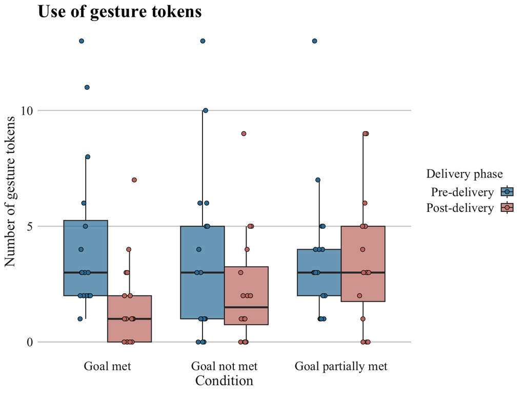

```r
ggplot(xdata, aes(x = Experimental_Condition, y = Gesture_Record_Count, fill = Delivery_Phase)) +
  geom_boxplot(position = position_dodge(width = 0.75), outlier.shape = NA, alpha = 0.7) +
  geom_jitter(aes(color = Delivery_Phase),
  shape = 21, color = "black",
  position = position_jitterdodge(jitter.width = 0.2, dodge.width = 0.75),
  alpha = 1, size = 2, stroke = 0.4) +
  labs(x = "Condition", y = "Number of gesture tokens",
  fill = "Delivery phase", color = "Delivery phase") +
  ggtitle("Use of gesture tokens") +
  theme_exp()
```

```r
ggsave(here("plots", "ngestures_cond_phase.png"), width = 10, height = 6)
```

## Plot distribution response: Number of gesture tokens

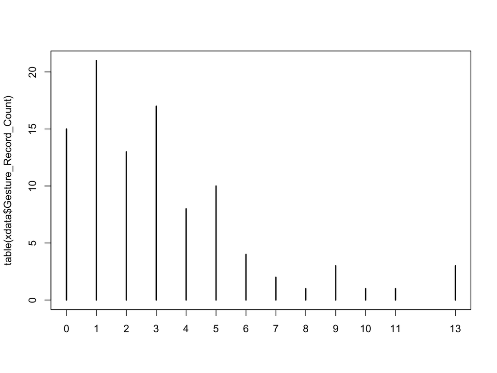

```r
mean_value_sr <- mean(xdata$Gesture_Record_Count, na.rm = TRUE)
variance_value_sr <- var(xdata$Gesture_Record_Count, na.rm = TRUE)
plot(table(xdata$Gesture_Record_Count))
```

Issue of overdispersion so we used a negative binomial model

## Fit Negative binomial GLMM

```r
full.gtok <- glmer.nb(Gesture_Record_Count ~ Experimental_Condition * Delivery_Phase
                     + Age + Sex
                     + (1 | Subject),
                    data = xdata)
summary(full.gtok)
```

```
## Generalized linear mixed model fit by maximum likelihood (Laplace
##   Approximation) [glmerMod]
##  Family: Negative Binomial(3.6572)  ( log )
## Formula: Gesture_Record_Count ~ Experimental_Condition * Delivery_Phase +
##     Age + Sex + (1 | Subject)
##    Data: xdata
##
##       AIC       BIC    logLik -2*log(L)  df.resid
##     436.7     462.7    -208.4     416.7        89
##
## Scaled residuals:
##     Min      1Q  Median      3Q     Max
## -1.3793 -0.6548 -0.2578  0.4890  3.4293
##
## Random effects:
##  Groups  Name        Variance Std.Dev.
##  Subject (Intercept) 0.05751  0.2398
## Number of obs: 99, groups:  Subject, 17
##
## Fixed effects:
##                                                                      Estimate
## (Intercept)                                                            1.4034
## Experimental_ConditionGoal not met                                    -0.1412
## Experimental_ConditionGoal partially met                              -0.1388
## Delivery_PhasePost-delivery                                           -0.9726
## AgeYoung adult                                                        -0.4656
## SexMale                                                                0.4720
## Experimental_ConditionGoal not met:Delivery_PhasePost-delivery         0.4491
## Experimental_ConditionGoal partially met:Delivery_PhasePost-delivery   1.0448
##                                                                      Std. Error
## (Intercept)                                                              0.2638
## Experimental_ConditionGoal not met                                       0.2604
## Experimental_ConditionGoal partially met                                 0.2585
## Delivery_PhasePost-delivery                                              0.2963
## AgeYoung adult                                                           0.2129
## SexMale                                                                  0.2078
## Experimental_ConditionGoal not met:Delivery_PhasePost-delivery           0.4126
## Experimental_ConditionGoal partially met:Delivery_PhasePost-delivery     0.3969
##                                                                      z value
## (Intercept)                                                            5.319
```

[output cut: 22 more lines]

```
## SexMale                                                              *
## Experimental_ConditionGoal not met:Delivery_PhasePost-delivery
## Experimental_ConditionGoal partially met:Delivery_PhasePost-delivery **
## ---
## Signif. codes:  0 '***' 0.001 '**' 0.01 '*' 0.05 '.' 0.1 ' ' 1
##
## Correlation of Fixed Effects:
##             (Intr) Ex_CGnm Ex_CGpm Dl_PP- AgYnga SexMal E_CGnm:
## Exprmn_CGnm -0.478
## Exprmn_CGpm -0.463  0.495
## Dlvry_PhsP- -0.409  0.427   0.429
## AgeYongadlt -0.543 -0.030  -0.041  -0.016
## SexMale     -0.548  0.037   0.002  -0.001  0.260
## E_CGnm:D_PP  0.318 -0.632  -0.308  -0.719  0.007 -0.050
## E_CGpm:D_PP  0.306 -0.315  -0.645  -0.745 -0.012  0.024  0.533
```

We tested for the effect of the interaction between Experimental_Condition and Delivery_Phase. We controlled for Individual to avoid pseudoreplication by including it as a random effect, and controlled for Age and for Sex by entering them as control fixed effects because they do not have enough levels to be included as random effects.

## Assumptions

### Overdispersion and random effect distribution

```r
overdisp.test(full.gtok)
```

```
##     chisq df        P dispersion.parameter
## 1 91.4192 89 0.409204             1.027182
```

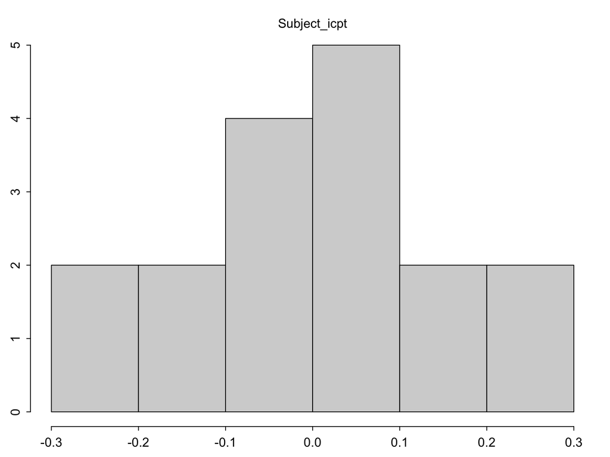

```r
ranef.diagn.plot(full.gtok)
```

No overdispersion issue. Distribution of random effect Subject is ok.

### Multicollinearity

```r
xx.gtok=lm(Gesture_Record_Count ~ Experimental_Condition + Delivery_Phase
            + Age + Sex,
            data = xdata)
vif.gtok=vif(xx.gtok)
vif.gtok
```

```
##                            GVIF Df GVIF^(1/(2*Df))
## Experimental_Condition 1.003031  2        1.000757
## Delivery_Phase         1.001065  1        1.000532
## Age                    1.109830  1        1.053485
## Sex                    1.109662  1        1.053405
```

No multicollinearity issue as all predictors have VIF values close to 1

### Model stability

```r
full.gtok.stab=glmm.model.stab(model.res=full.gtok, data=xdata)
```

```
## [1] "please carefully evaluate whether the result makes sense, and if not, please contact me"
```

```r
table(full.gtok.stab$detailed$lme4.warnings) #all 17 converged
```

```
##
##
## 17
```

```r
table(full.gtok.stab$detailed$opt.warnings) #all 17 converged
```

```
##
##
## 17
```

```r
full.gtok.stab.rd=round(full.gtok.stab$summary[, -1], 3)
full.gtok.stab.rd
```

```
##                                                                        orig
## (Intercept)                                                           1.403
## Experimental_ConditionGoal not met                                   -0.141
## Experimental_ConditionGoal partially met                             -0.139
## Delivery_PhasePost-delivery                                          -0.973
## AgeYoung adult                                                       -0.466
## SexMale                                                               0.472
## Experimental_ConditionGoal not met:Delivery_PhasePost-delivery        0.449
## Experimental_ConditionGoal partially met:Delivery_PhasePost-delivery  1.045
## Subject@(Intercept)@NA                                                0.240
##                                                                         min
## (Intercept)                                                           1.295
## Experimental_ConditionGoal not met                                   -0.363
## Experimental_ConditionGoal partially met                             -0.292
## Delivery_PhasePost-delivery                                          -1.087
## AgeYoung adult                                                       -0.574
## SexMale                                                               0.347
## Experimental_ConditionGoal not met:Delivery_PhasePost-delivery        0.183
## Experimental_ConditionGoal partially met:Delivery_PhasePost-delivery  0.817
## Subject@(Intercept)@NA                                                0.120
##                                                                         max
## (Intercept)                                                           1.545
## Experimental_ConditionGoal not met                                    0.013
## Experimental_ConditionGoal partially met                             -0.025
## Delivery_PhasePost-delivery                                          -0.891
## AgeYoung adult                                                       -0.395
## SexMale                                                               0.546
## Experimental_ConditionGoal not met:Delivery_PhasePost-delivery        0.615
## Experimental_ConditionGoal partially met:Delivery_PhasePost-delivery  1.166
## Subject@(Intercept)@NA                                                0.297
```

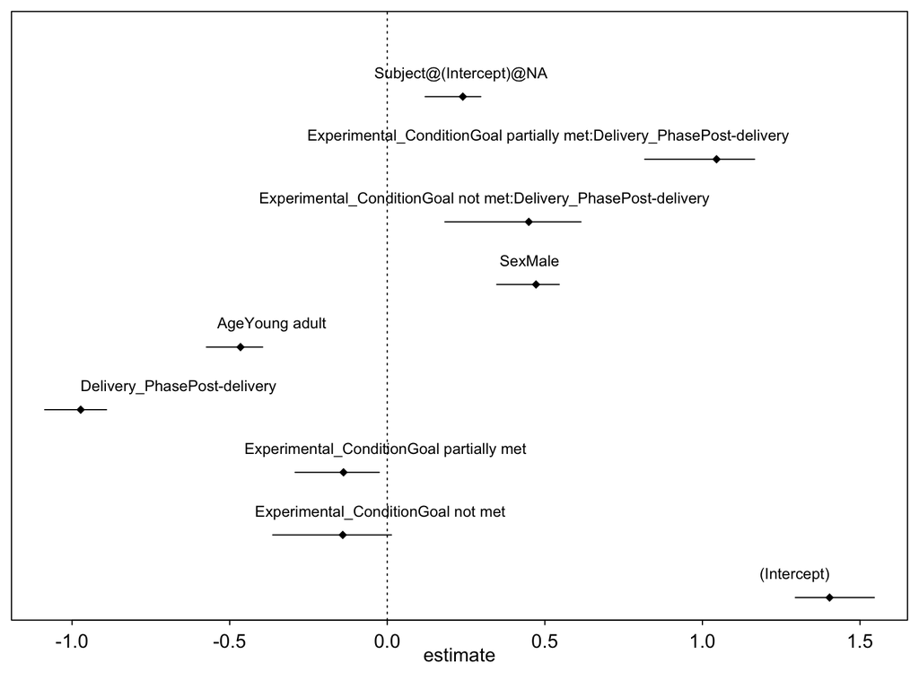

```r
m.stab.plot(full.gtok.stab$summary[, -1], 3)
```

```r
setwd("/Users/ve/Desktop/PhD/Analysis/Chapter 2 - Experiment/results/Model 1 - Persistence")
write.table(full.gtok.stab.rd, file="Mstab_GLMM_gtokens.csv", row.names=T, col.names=T, sep="\t")
```

Model is slightly unstable for condition Goal not met

## Results

### Full-null model comparison

```r
null.gtok<-glmer.nb(Gesture_Record_Count ~ Experimental_Condition + Delivery_Phase
                   + Age + Sex + (1 | Subject),
                   data = xdata)

Chisq.gtok<-round(as.data.frame(anova(null.gtok, full.gtok, test="Chisq")), 3)
Chisq.gtok
```

```
##           npar     AIC     BIC   logLik -2*log(L) Chisq Df Pr(>Chisq)
## null.gtok    8 439.654 460.414 -211.827   423.654    NA NA         NA
## full.gtok   10 436.701 462.652 -208.350   416.701 6.953  2      0.031
```

```r
setwd("/Users/ve/Desktop/PhD/Analysis/Chapter 2 - Experiment/results/Model 1 - Persistence")
write.table(Chisq.gtok, file="Chisq_GLMM_gtokens.csv", row.names=T, col.names=T, sep="\t")
```

The full-null model comparison is significant, meaning the predictors in the full model significantly improve the fit of the model compared to the null model.

### Summary results

```r
res.gtok.rd=round(summary(full.gtok)$coefficients, 3)
res.gtok.rd
```

```
##                                                                      Estimate
## (Intercept)                                                             1.403
## Experimental_ConditionGoal not met                                     -0.141
## Experimental_ConditionGoal partially met                               -0.139
## Delivery_PhasePost-delivery                                            -0.973
## AgeYoung adult                                                         -0.466
## SexMale                                                                 0.472
## Experimental_ConditionGoal not met:Delivery_PhasePost-delivery          0.449
## Experimental_ConditionGoal partially met:Delivery_PhasePost-delivery    1.045
##                                                                      Std. Error
## (Intercept)                                                               0.264
## Experimental_ConditionGoal not met                                        0.260
## Experimental_ConditionGoal partially met                                  0.258
## Delivery_PhasePost-delivery                                               0.296
## AgeYoung adult                                                            0.213
## SexMale                                                                   0.208
## Experimental_ConditionGoal not met:Delivery_PhasePost-delivery            0.413
## Experimental_ConditionGoal partially met:Delivery_PhasePost-delivery      0.397
##                                                                      z value
## (Intercept)                                                            5.319
## Experimental_ConditionGoal not met                                    -0.542
## Experimental_ConditionGoal partially met                              -0.537
## Delivery_PhasePost-delivery                                           -3.282
## AgeYoung adult                                                        -2.186
## SexMale                                                                2.272
## Experimental_ConditionGoal not met:Delivery_PhasePost-delivery         1.088
## Experimental_ConditionGoal partially met:Delivery_PhasePost-delivery   2.632
##                                                                      Pr(>|z|)
## (Intercept)                                                             0.000
## Experimental_ConditionGoal not met                                      0.588
## Experimental_ConditionGoal partially met                                0.591
## Delivery_PhasePost-delivery                                             0.001
## AgeYoung adult                                                          0.029
## SexMale                                                                 0.023
## Experimental_ConditionGoal not met:Delivery_PhasePost-delivery          0.276
## Experimental_ConditionGoal partially met:Delivery_PhasePost-delivery    0.008
```

```r
setwd("/Users/ve/Desktop/PhD/Analysis/Chapter 2 - Experiment/results/Model 1 - Persistence")
write.table(res.gtok.rd, file="Res_GLMM_gtokens.csv", row.names=T, col.names=T, sep="\t")
```

As predicted, subjects persisted gesturing more (i.e., increased their use of gesture tokens from pre to post-delivery) in the Goal partially met condition as compared to the Goal met condition. However, against our predictions, there was no difference in the frequency of use of gesture tokens between the Goal not met condition and the Goal met condition.

N.B. Single variables in the interaction should not be interpreted (Delivery_Phase and Experimental_Condition) as well as Age and Sex because they are controls.

### Post-hoc tests

```r
emm.gtok <- emmeans(full.gtok, ~ Experimental_Condition * Delivery_Phase)

pw.comp.gtok.phase <- contrast(emm.gtok, interaction = c("pairwise", "pairwise"),
                                 by = "Delivery_Phase")
posthoc.gtok.phase <- summary(pw.comp.gtok.phase, adjust = "tukey")
posthoc.gotk.phase.rd <- as.data.frame(lapply(posthoc.gtok.phase, function(x) {
  if(is.numeric(x)) round(x, 3) else x
}))
posthoc.gotk.phase.rd
```

```
##     Experimental_Condition_pairwise Delivery_Phase estimate    SE  df z.ratio
## 1           Goal met - Goal not met   Pre-delivery    0.141 0.260 Inf   0.542
## 2     Goal met - Goal partially met   Pre-delivery    0.139 0.258 Inf   0.537
## 3 Goal not met - Goal partially met   Pre-delivery   -0.002 0.261 Inf  -0.009
## 4           Goal met - Goal not met  Post-delivery   -0.308 0.320 Inf  -0.963
## 5     Goal met - Goal partially met  Post-delivery   -0.906 0.303 Inf  -2.986
## 6 Goal not met - Goal partially met  Post-delivery   -0.598 0.290 Inf  -2.064
##   p.value
## 1   0.851
## 2   0.853
## 3   1.000
## 4   0.600
## 5   0.008
## 6   0.097
```

```r
setwd("/Users/ve/Desktop/PhD/Analysis/Chapter 2 - Experiment/results/Model 1 - Persistence")
write.table(posthoc.gotk.phase.rd, file="Posthoc_Res_GLMM_gtokens.csv", row.names=T, col.names=T, sep="\t")
```

The Tukey post-hoc tests show: Pre-delivery: As predicted, we found no significant differences across conditions in the pre-delivery phase, suggesting that subjects could not predict what item they would be getting during pre-delivery. Post-delivery: During post-delivery subjects also persisted gesturing more in the Goal partially met condition as compared to the Goal met condition.

### Effect sizes

```r
library(MuMIn)
r.sq.gtok=r.squaredGLMM(object=full.gtok)
r.sq.gtok
```

```
##                 R2m       R2c
## delta     0.2958666 0.3580695
## lognormal 0.3432202 0.4153788
## trigamma  0.2413319 0.2920694
```

### Confidence intervals

```r
source("boot_glmm.r")
set.seed(123)
boot.res.gtok=boot.glmm.pred(model.res=full.gtok, excl.warnings=F,
                        nboots=1000, para=F)
cis.gtok=round(boot.res.gtok$ci.estimates, 3)
cis.gtok
```

```
##                                                                        orig
## (Intercept)                                                           1.403
## Experimental_ConditionGoal not met                                   -0.141
## Experimental_ConditionGoal partially met                             -0.139
## Delivery_PhasePost-delivery                                          -0.973
## AgeYoung adult                                                       -0.466
## SexMale                                                               0.472
## Experimental_ConditionGoal not met:Delivery_PhasePost-delivery        0.449
## Experimental_ConditionGoal partially met:Delivery_PhasePost-delivery  1.045
##                                                                       X2.5.
## (Intercept)                                                           0.858
## Experimental_ConditionGoal not met                                   -0.686
## Experimental_ConditionGoal partially met                             -0.659
## Delivery_PhasePost-delivery                                          -1.565
## AgeYoung adult                                                       -0.868
## SexMale                                                               0.082
## Experimental_ConditionGoal not met:Delivery_PhasePost-delivery       -0.304
## Experimental_ConditionGoal partially met:Delivery_PhasePost-delivery  0.282
##                                                                      X97.5.
## (Intercept)                                                           1.876
## Experimental_ConditionGoal not met                                    0.344
## Experimental_ConditionGoal partially met                              0.369
## Delivery_PhasePost-delivery                                          -0.413
## AgeYoung adult                                                       -0.064
## SexMale                                                               0.882
## Experimental_ConditionGoal not met:Delivery_PhasePost-delivery        1.289
## Experimental_ConditionGoal partially met:Delivery_PhasePost-delivery  1.865
```

```r
setwd("/Users/ve/Desktop/PhD/Analysis/Chapter 2 - Experiment/results/Model 1 - Persistence")
write.table(cis.gtok, file="CI_GLMM_gtokens.csv", row.names=T, col.names=T, sep="\t")
```

### Plot for effect of interaction

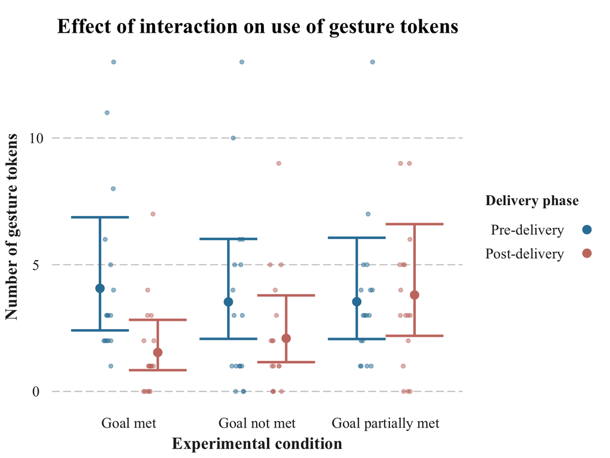

```r
#Plot effect of interaction experimental condition*delivery phase on n gesture tokens
plot.res.int.gtok <- cat_plot(full.gtok, pred = Experimental_Condition,
  modx = Delivery_Phase, data = xdata,
  x.label = "Experimental condition", y.label = "Number of gesture tokens") +
  theme_exp() +
  guides(fill="none") + labs(color = "Delivery phase", title="Effect of interaction on use of gesture tokens") +
  ylim(0, NA)

plot.res.int.gtok.ed <- plot.res.int.gtok +
  geom_jitter(data = xdata,
              aes(x = Experimental_Condition,
                  y = Gesture_Record_Count,
                  color = Delivery_Phase),
              position = position_jitterdodge(jitter.width = 0.2, dodge.width = 0.6),
              alpha = 0.5,
              size = 1.5,
              inherit.aes = FALSE)
plot.res.int.gtok.ed
```

```r
ggsave(here::here("plots", "Mod_ngest_tokens_int_rev.png"), width = 10, height = 6)
```

# Elaboration Model

To test for elaboration we compared the number of novel (i.e. not used during pre-delivery) as compared to repeated (used during pre-delivery) gesture tokens used during post-delivery across the three experimental conditions. Again, we predicted that, during post-delivery, subjects would elaborate their gesturing by using more often novel gesture types (rather than repeating gesture types already used during pre-delivery) when their goal is not met as compared to met or partially met (i.e., elaboration).

## Plot percentage of novel vs repeated gesture types during post-delivery across conditions

Percentage calculated by dividing the frequency tokens of novel or repeated gesture types by the total frequency of gesture tokens during post-delivery

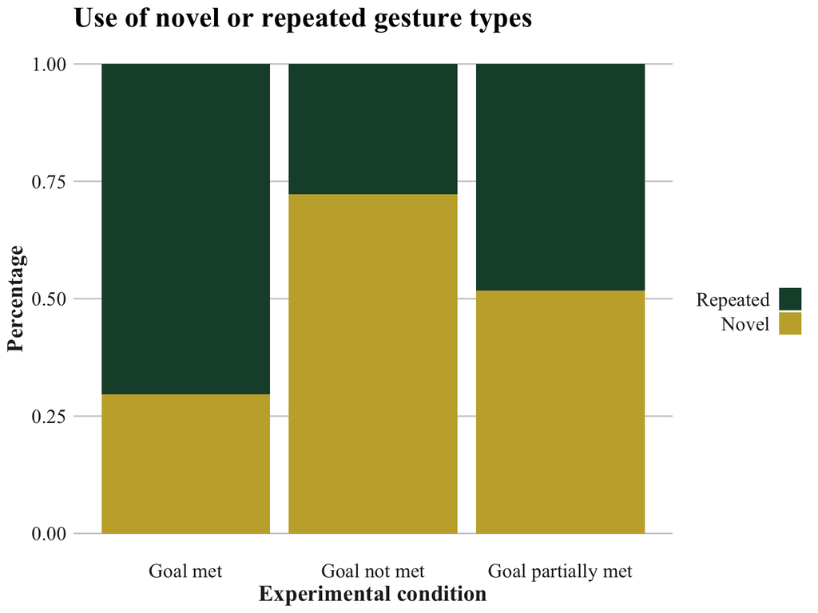

```r
#sort data
xdata2 <- read.csv("/Users/ve/Desktop/PhD/Analysis/Chapter 2 - Experiment/dataframes/exp_nov_rep_gest_summary_df.csv")
levels(xdata2$Experimental_Condition)[levels(xdata2$Experimental_Condition)=="Goal Not Met"] <- "Goal not met" # relevel
levels(xdata2$Experimental_Condition)[levels(xdata2$Experimental_Condition)=="Goal Met"] <- "Goal met" # relevel
levels(xdata2$Experimental_Condition)[levels(xdata2$Experimental_Condition)=="Goal Partially Met"] <- "Goal partially met" # relevel

xdata2 <- subset(xdata2, ! Novel_Gest_Types_Used %in% c("NV"))
xdata2 <- droplevels(xdata2)
summary_novel_repeated <- xdata2 %>%
  dplyr::group_by(Experimental_Condition) %>%
  dplyr::summarize(
    Novel_Gest_Types_Freq_Total = sum(Novel_Gest_Types_Count, na.rm = TRUE),
    Repeated_Gest_Types_Freq_Total = sum(Repeated_Gest_Types_Count, na.rm = TRUE),
    Post_Delivery_Gest_Types_Freq_Total= sum(Post_Delivery_Gest_Types_Count, na.rm = TRUE),
    Novel_Gest_Types_Used_Percent = sum(Novel_Gest_Types_Count) / Post_Delivery_Gest_Types_Freq_Total,
    Repeated_Gest_Types_Used_Percent = sum(Repeated_Gest_Types_Count) / Post_Delivery_Gest_Types_Freq_Total,
    .groups = 'drop'
  )

#convert data to long format
library(tidyr)
summary_novel_repeated_long <- summary_novel_repeated %>%
  pivot_longer(cols = c(Novel_Gest_Types_Used_Percent, Repeated_Gest_Types_Used_Percent,
                        Novel_Gest_Types_Freq_Total, Repeated_Gest_Types_Freq_Total),
               names_to = c("Novel_Repeated_Gest_Types", ".value"),
    names_pattern = "(.*)_Gest_Types_(.*)"
  )

summary_novel_repeated_long <- summary_novel_repeated_long %>%
  dplyr::rename(Novel_Repeated_Gest_Types_Freq_Total = Post_Delivery_Gest_Types_Freq_Total)

plot_novrepgest_percent=ggplot(summary_novel_repeated_long, aes(x = Experimental_Condition, y = Used_Percent,
fill = factor(Novel_Repeated_Gest_Types, levels= c("Repeated", "Novel")))) +
  geom_bar(stat = "identity")  +
  labs(title = "Use of novel or repeated gesture types",
       x = "Experimental condition",
       y = "Percentage",
       fill = " ") + theme_exp() +
  scale_fill_scico_d(
    palette = "bamako",
    begin = 0.2,
    end = 0.8) +
  theme(
    axis.title.x = element_text(face = "bold", family = "Times New Roman"),
    axis.title.y = element_text(face = "bold", family = "Times New Roman"),
    legend.title = element_text(face = "bold", family = "Times New Roman")
  )
plot_novrepgest_percent
```

```r
ggsave(here::here("plots", "Percent_nov_rep_type_gtokens.png"), plot = plot_novrepgest_percent, width = 10, height = 6)
```

## Data sorting

```r
xdata3 <- xdata2 %>%
  pivot_longer(cols = c("Novel_Gest_Types_Count", "Repeated_Gest_Types_Count"),
               names_to = "Nov_Rep_Type",
               values_to = "Gesture_Record_Count") %>%
  mutate(Nov_Rep_Type = ifelse(Nov_Rep_Type == "Novel_Gest_Types_Count", "Novel", "Repeated"))
xdata3$Nov_Rep_Type <- factor(xdata3$Nov_Rep_Type)
xdata3$Nov_Rep_Type <- relevel(xdata3$Nov_Rep_Type, ref = "Repeated") #Set Repeated as reference level
```

## Plot distribution response: Number of gesture tokens

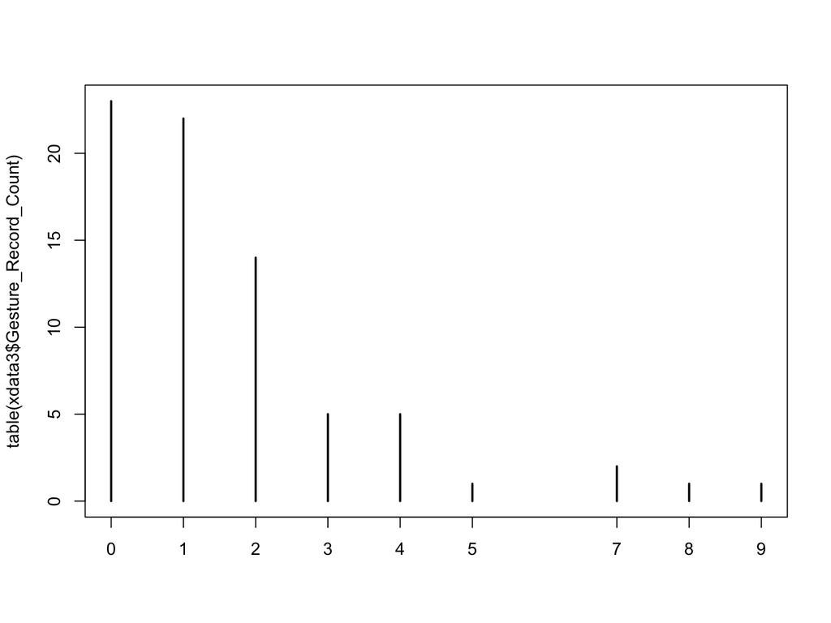

```r
mean_value_sr <- mean(xdata3$Gesture_Record_Count, na.rm = TRUE)
variance_value_sr <- var(xdata3$Gesture_Record_Count, na.rm = TRUE)
plot(table(xdata3$Gesture_Record_Count))
```

Skewed and there many 0s so we used a negative binomial model with 0 inflation (see later)

## Fit Negative binomial GLMM with 0 inflation

```r
library(glmmTMB)
full.nrtype.gtok <- glmmTMB(Gesture_Record_Count ~ Experimental_Condition * Nov_Rep_Type + Age
                          + Sex +
                          (1 | Subject),
                          ziformula = ~1,
                          family = nbinom2,
                          data = xdata3)
summary(full.nrtype.gtok)
```

```
##  Family: nbinom2  ( log )
## Formula:
## Gesture_Record_Count ~ Experimental_Condition * Nov_Rep_Type +
##     Age + Sex + (1 | Subject)
## Zero inflation:                        ~1
## Data: xdata3
##
##      AIC      BIC   logLik deviance df.resid
##    265.4    290.7   -121.7    243.4       63
##
## Random effects:
##
## Conditional model:
##  Groups  Name        Variance  Std.Dev.
##  Subject (Intercept) 1.029e-14 1.014e-07
## Number of obs: 74, groups:  Subject, 15
##
## Dispersion parameter for nbinom2 family (): 2.26
##
## Conditional model:
##                                                            Estimate Std. Error
## (Intercept)                                                 0.30794    0.39207
## Experimental_ConditionGoal not met                         -0.66325    0.47805
## Experimental_ConditionGoal partially met                    0.28551    0.40192
## Nov_Rep_TypeNovel                                          -0.85401    0.50370
## AgeYoung adult                                             -0.06783    0.27462
## SexMale                                                     0.33456    0.27566
## Experimental_ConditionGoal not met:Nov_Rep_TypeNovel        1.77537    0.68503
## Experimental_ConditionGoal partially met:Nov_Rep_TypeNovel  1.01323    0.62904
##                                                            z value Pr(>|z|)
## (Intercept)                                                  0.785  0.43221
## Experimental_ConditionGoal not met                          -1.387  0.16532
## Experimental_ConditionGoal partially met                     0.710  0.47747
## Nov_Rep_TypeNovel                                           -1.696  0.08999 .
## AgeYoung adult                                              -0.247  0.80491
## SexMale                                                      1.214  0.22487
## Experimental_ConditionGoal not met:Nov_Rep_TypeNovel         2.592  0.00955 **
## Experimental_ConditionGoal partially met:Nov_Rep_TypeNovel   1.611  0.10723
## ---
## Signif. codes:  0 '***' 0.001 '**' 0.01 '*' 0.05 '.' 0.1 ' ' 1
##
## Zero-inflation model:
##             Estimate Std. Error z value Pr(>|z|)
## (Intercept)   -19.69    8037.19  -0.002    0.998
```

We tested for the effect of the interaction between Experimental_Condition and the type of gesturing (i.e., Nov_Rep_Type). Again, to avoid pseudoreplication we controlled for Individual by including it as a random effect, and controlled for Sex and Age by including them as control fixed effects.

## Assumptions

### Overdispersion and random effect distribution

```r
overdisp.test(full.nrtype.gtok)
```

```
## [1] "caution: support for models of class glmmTMB is experimental and embryonic"
## [1] "and don't worry if it takes some time"
```

```
##      chisq df         P dispersion.parameter
## 1 73.39152 63 0.1741453             1.164945
```

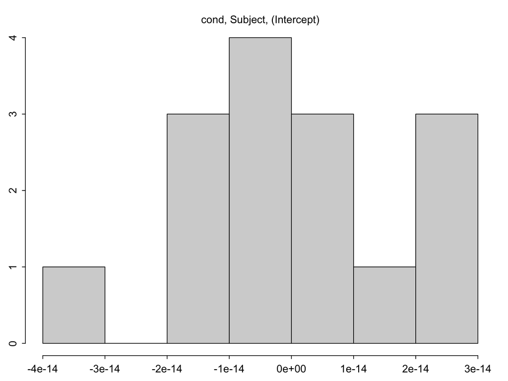

```r
ranef.diagn.plot(full.nrtype.gtok)
```

No overdispersion issue. Distribution of random effect Subject ok.

### Multicollinearity

```r
xx.nrtype.gtok=lm(Gesture_Record_Count ~ Experimental_Condition + Nov_Rep_Type
            + Age + Sex,
            data = xdata3)
vif.nrtype.gtok=vif(xx.nrtype.gtok)
vif.nrtype.gtok
```

```
##                            GVIF Df GVIF^(1/(2*Df))
## Experimental_Condition 1.006927  2        1.001727
## Nov_Rep_Type           1.000000  1        1.000000
## Age                    1.175536  1        1.084221
## Sex                    1.175142  1        1.084040
```

No multicollinearity issue as all VIF values are close to 1.

### Model stability

```r
full.nrtype.gtok.stab=glmmTMB.stab(model.res=full.nrtype.gtok, para=T, data=xdata3)
```

```
## [1] "please carefully evaluate whether the result makes sense, and if not, please contact me"
```

```r
table(full.nrtype.gtok.stab$detailed$converged)
```

```
##
## FALSE  TRUE
##     5    10
```

```r
full.nrtype.gtok.stab.rd=round(full.nrtype.gtok.stab$summary[, -1], 3)
full.nrtype.gtok.stab.rd
```

```
##                                                                    orig     min
## cond@(Intercept)                                                  0.308  -0.070
## cond@Experimental_ConditionGoal not met                          -0.663  -1.011
## cond@Experimental_ConditionGoal partially met                     0.286   0.066
## cond@Nov_Rep_TypeNovel                                           -0.854  -1.314
## cond@AgeYoung adult                                              -0.068  -0.221
## cond@SexMale                                                      0.335   0.261
## cond@Experimental_ConditionGoal not met:Nov_Rep_TypeNovel         1.775   1.150
## cond@Experimental_ConditionGoal partially met:Nov_Rep_TypeNovel   1.013   0.625
## zi@(Intercept)                                                  -19.688 -20.402
## disp@(Intercept)                                                  0.818   0.702
## cond@Subject@(Intercept)@NA                                       0.000   0.000
##                                                                     max
## cond@(Intercept)                                                  0.428
## cond@Experimental_ConditionGoal not met                          -0.220
## cond@Experimental_ConditionGoal partially met                     0.568
## cond@Nov_Rep_TypeNovel                                           -0.421
## cond@AgeYoung adult                                               0.042
## cond@SexMale                                                      0.410
## cond@Experimental_ConditionGoal not met:Nov_Rep_TypeNovel         2.340
## cond@Experimental_ConditionGoal partially met:Nov_Rep_TypeNovel   1.463
## zi@(Intercept)                                                  -18.807
## disp@(Intercept)                                                  1.248
## cond@Subject@(Intercept)@NA                                       0.000
```

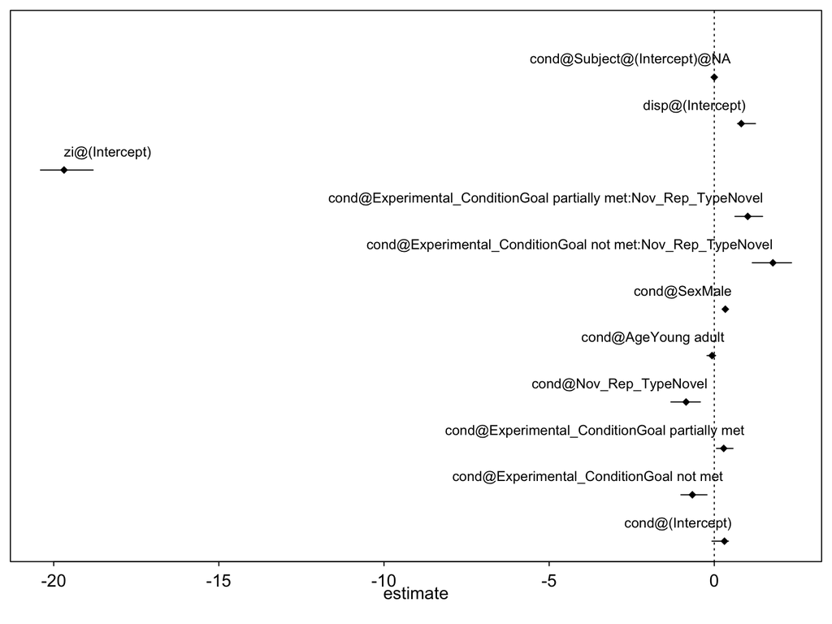

```r
m.stab.plot(full.nrtype.gtok.stab$summary[, -1])
```

```r
setwd("/Users/ve/Desktop/PhD/Analysis/Chapter 2 - Experiment/results/Model 2 - Elaboration")
write.table(full.nrtype.gtok.stab.rd, file="Mstab_GLMM_nov_rep_gtoken.csv", row.names=T, col.names=T, sep="\t")
```

Model is stable

## Results

### Full-null model comparison

```r
null.nrtype.gtok<-glmmTMB(Gesture_Record_Count ~ Experimental_Condition + Nov_Rep_Type + Age + Sex +
                          (1 | Subject),
                          ziformula = ~1,
                          family = nbinom2,
                          data = xdata3)

Chisq.nrtype.gtok<-round(as.data.frame(anova(null.nrtype.gtok, full.nrtype.gtok, test="Chisq")), 3)
Chisq.nrtype.gtok
```

```
##                  Df     AIC     BIC   logLik deviance Chisq Chi Df Pr(>Chisq)
## null.nrtype.gtok  9 268.117 288.853 -125.058  250.117    NA     NA         NA
## full.nrtype.gtok 11 265.376 290.721 -121.688  243.376 6.741      2      0.034
```

```r
setwd("/Users/ve/Desktop/PhD/Analysis/Chapter 2 - Experiment/results/Model 2 - Elaboration")
write.table(Chisq.nrtype.gtok, file="Chisq_GLMM_nov_rep_gtoken.csv", row.names=T, col.names=T, sep="\t")
```

The full-null model comparison is significant, meaning the predictors in the full model significantly improve the fit of the model compared to the null model.

### Summary results

```r
res.nrtype.gtok=summary(full.nrtype.gtok)$coefficients
res.nrtype.gtok.rd=round(res.nrtype.gtok$cond, 3)
res.nrtype.gtok.rd
```

```
##                                                            Estimate Std. Error
## (Intercept)                                                   0.308      0.392
## Experimental_ConditionGoal not met                           -0.663      0.478
## Experimental_ConditionGoal partially met                      0.286      0.402
## Nov_Rep_TypeNovel                                            -0.854      0.504
## AgeYoung adult                                               -0.068      0.275
## SexMale                                                       0.335      0.276
## Experimental_ConditionGoal not met:Nov_Rep_TypeNovel          1.775      0.685
## Experimental_ConditionGoal partially met:Nov_Rep_TypeNovel    1.013      0.629
##                                                            z value Pr(>|z|)
## (Intercept)                                                  0.785    0.432
## Experimental_ConditionGoal not met                          -1.387    0.165
## Experimental_ConditionGoal partially met                     0.710    0.477
## Nov_Rep_TypeNovel                                           -1.695    0.090
## AgeYoung adult                                              -0.247    0.805
## SexMale                                                      1.214    0.225
## Experimental_ConditionGoal not met:Nov_Rep_TypeNovel         2.592    0.010
## Experimental_ConditionGoal partially met:Nov_Rep_TypeNovel   1.611    0.107
```

```r
setwd("/Users/ve/Desktop/PhD/Analysis/Chapter 2 - Experiment/results/Model 2 - Elaboration")
write.table(res.nrtype.gtok.rd, file="Res_GLMM_nov_rep_gtokens.csv", row.names=T, col.names=T, sep="\t")
```

As predicted, we found that subjects used more often novel gesture types (rather than repetitions of gesture types used during pre-delivery) in the Goal not met condition as compared to the Goal met condition. N.B. Single variables in interaction results (and Age, Sex, control) should not be interpreted (Nov_Rep_Type and Experimental_Condition).

### Post-hoc tests

```r
emm.nrtype.gtok <- emmeans(full.nrtype.gtok, ~ Experimental_Condition * Nov_Rep_Type)

pw.comp.nrtype.gtok <- contrast(emm.nrtype.gtok, interaction = c("pairwise", "pairwise"))

posthoc.nrtype.gtok <- summary(pw.comp.nrtype.gtok, adjust = "sidak") #changed to sidak
posthoc.nrtype.gtok.rd <- as.data.frame(lapply(posthoc.nrtype.gtok, function(x) {
  if(is.numeric(x)) round(x, 3) else x
}))
posthoc.nrtype.gtok.rd
```

```
##     Experimental_Condition_pairwise Nov_Rep_Type_pairwise estimate    SE  df
## 1           Goal met - Goal not met      Repeated - Novel    1.775 0.685 Inf
## 2     Goal met - Goal partially met      Repeated - Novel    1.013 0.629 Inf
## 3 Goal not met - Goal partially met      Repeated - Novel   -0.762 0.600 Inf
##   z.ratio p.value
## 1   2.592   0.028
## 2   1.611   0.288
## 3  -1.271   0.495
```

```r
setwd("/Users/ve/Desktop/PhD/Analysis/Chapter 2 - Experiment/results/Model 2 - Elaboration")
write.table(posthoc.nrtype.gtok.rd, file="Posthoc_Res_GLMM_nov_rep_gtokens.csv", row.names=T, col.names=T, sep="\t")
```

The Sidak post-hoc test shows: Against our predictions, we found no difference in the frequency of use of novel as compared to repeated gesture types between the Goal Partially Met and Goal Not Met conditions.

### Effect sizes

```r
library(MuMIn)
r.sq.nrtype.gtok=r.squaredGLMM(object=full.nrtype.gtok)
r.sq.nrtype.gtok
```

```
##                 R2m       R2c
## delta     0.2117792 0.2117792
## lognormal 0.2822971 0.2822971
## trigamma  0.1374927 0.1374927
```

### Confidence intervals

```r
cis.nrtype.gtok=confint(full.nrtype.gtok, method = "Wald")
cis.nrtype.gtok.rd=round(cis.nrtype.gtok, 3)
cis.nrtype.gtok.rd
```

```
##                                                                      2.5 %
## cond.(Intercept)                                                    -0.461
## cond.Experimental_ConditionGoal not met                             -1.600
## cond.Experimental_ConditionGoal partially met                       -0.502
## cond.Nov_Rep_TypeNovel                                              -1.841
## cond.AgeYoung adult                                                 -0.606
## cond.SexMale                                                        -0.206
## cond.Experimental_ConditionGoal not met:Nov_Rep_TypeNovel            0.433
## cond.Experimental_ConditionGoal partially met:Nov_Rep_TypeNovel     -0.220
## zi.(Intercept)                                                  -15772.296
## cond.Std.Dev.(Intercept)|Subject                                     0.000
##                                                                    97.5 %
## cond.(Intercept)                                                    1.076
## cond.Experimental_ConditionGoal not met                             0.274
## cond.Experimental_ConditionGoal partially met                       1.073
## cond.Nov_Rep_TypeNovel                                              0.133
## cond.AgeYoung adult                                                 0.470
## cond.SexMale                                                        0.875
## cond.Experimental_ConditionGoal not met:Nov_Rep_TypeNovel           3.118
## cond.Experimental_ConditionGoal partially met:Nov_Rep_TypeNovel     2.246
## zi.(Intercept)                                                  15732.920
## cond.Std.Dev.(Intercept)|Subject                                      Inf
##                                                                 Estimate
## cond.(Intercept)                                                   0.308
## cond.Experimental_ConditionGoal not met                           -0.663
## cond.Experimental_ConditionGoal partially met                      0.286
## cond.Nov_Rep_TypeNovel                                            -0.854
## cond.AgeYoung adult                                               -0.068
## cond.SexMale                                                       0.335
## cond.Experimental_ConditionGoal not met:Nov_Rep_TypeNovel          1.775
## cond.Experimental_ConditionGoal partially met:Nov_Rep_TypeNovel    1.013
## zi.(Intercept)                                                   -19.688
## cond.Std.Dev.(Intercept)|Subject                                   0.000
```

```r
setwd("/Users/ve/Desktop/PhD/Analysis/Chapter 2 - Experiment/results/Model 2 - Elaboration")
write.table(cis.nrtype.gtok.rd, file="CI_GLMM_nov_rep_gtokens.csv", row.names=T, col.names=T, sep="\t")
```

# Supplementary Diversity Model

To test for diversity, we compared the number of different gesture types used before and after delivery in the three experimental conditions. Again, here the predictions are that, from pre- to post-delivery, elephants will increase their use of gesture types in the Goal Not Met as compared to the Goal Met and Goal partially met conditions to increase the likelihood of producing gesture types effective at achieving the desired item.

## Plot distribution response: Number of gesture types

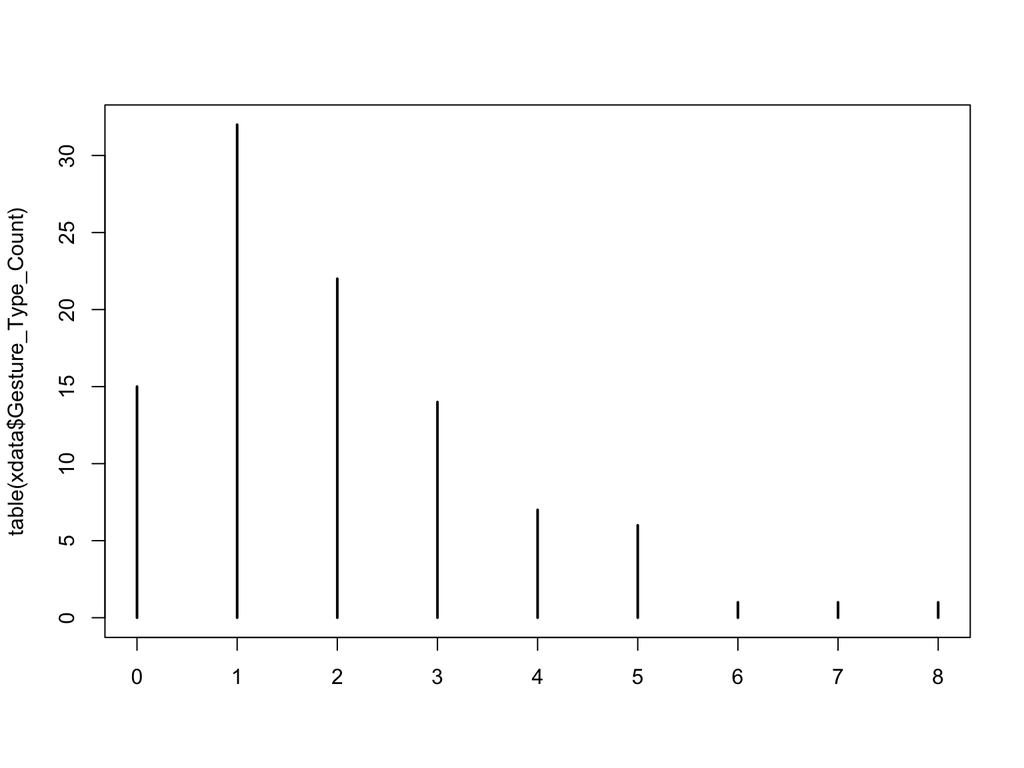

```r
mean_value_st <- mean(xdata$Gesture_Type_Count, na.rm = TRUE)
variance_value_st <- var(xdata$Gesture_Type_Count, na.rm = TRUE)
plot(table(xdata$Gesture_Type_Count))
```

There are a few 0s and doesn´t seem overdispersed so used a poisson model

## Fit poisson model

```r
full.gtype=glmer(Gesture_Type_Count ~ Experimental_Condition * Delivery_Phase + Sex + Age + Gesture_Record_Count
            + (1 | Subject),
            data = xdata,
            family=poisson)
full.gtype
```

```
## Generalized linear mixed model fit by maximum likelihood (Laplace
##   Approximation) [glmerMod]
##  Family: poisson  ( log )
## Formula: Gesture_Type_Count ~ Experimental_Condition * Delivery_Phase +
##     Sex + Age + Gesture_Record_Count + (1 | Subject)
##    Data: xdata
##       AIC       BIC    logLik -2*log(L)  df.resid
##  296.5560  322.5072 -138.2780  276.5560        89
## Random effects:
##  Groups  Name        Std.Dev.
##  Subject (Intercept) 0.1164
## Number of obs: 99, groups:  Subject, 17
## Fixed Effects:
##                                                          (Intercept)
##                                                             -0.07780
##                                   Experimental_ConditionGoal not met
##                                                              0.05355
##                             Experimental_ConditionGoal partially met
##                                                              0.08766
##                                          Delivery_PhasePost-delivery
##                                                             -0.23405
##                                                              SexMale
##                                                              0.24502
##                                                       AgeYoung adult
##                                                             -0.01618
##                                                 Gesture_Record_Count
##                                                              0.15029
##       Experimental_ConditionGoal not met:Delivery_PhasePost-delivery
##                                                              0.20851
## Experimental_ConditionGoal partially met:Delivery_PhasePost-delivery
##                                                              0.22487
```

We tested for the effect of the interaction between Experimental_Condition and Delivery_Phase. To avoid pseudoreplication we controlled for Individual by entering it as a random effect, and we controlled for Age and Sex by including them as control fixed effects.

## Assumptions

### Overdispersion and random effect distribution

```r
overdisp.test(full.gtype)
```

```
##      chisq df         P dispersion.parameter
## 1 42.23123 89 0.9999938            0.4745082
```

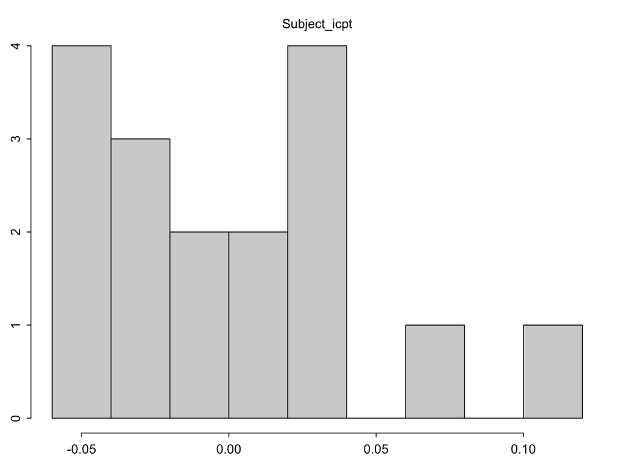

```r
ranef.diagn.plot(full.gtype)
```

No issue of overdispersion. Distribution of random effect Subject is ok.

### Multicollinearity

```r
xx.gtype=lm(Gesture_Type_Count ~ Experimental_Condition + Delivery_Phase +
            + Age + Sex + Gesture_Record_Count,
            data = xdata)
vif.gtype=vif(xx.gtype)
vif.gtype
```

```
##                            GVIF Df GVIF^(1/(2*Df))
## Experimental_Condition 1.018591  2        1.004616
## Delivery_Phase         1.061990  1        1.030529
## Age                    1.171895  1        1.082541
## Sex                    1.171786  1        1.082490
## Gesture_Record_Count   1.242470  1        1.114662
```

No multicollinearity issue

### Model stability

```r
control=glmerControl(optimizer="bobyqa", optCtrl=list(maxfun=100000))
full.gtype.stab=glmm.model.stab(model.res=full.gtype, data=xdata, contr=control)
```

```
## [1] "please carefully evaluate whether the result makes sense, and if not, please contact me"
```

```r
table(full.gtype.stab$detailed$lme4.warnings)
```

```
##
##
##                                              16
## boundary (singular) fit: see help('isSingular')
##                                               1
```

```r
table(full.gtype.stab$detailed$opt.warnings)
```

```
##
##
## 17
```

```r
full.gtype.stab.rd=round(full.gtype.stab$summary[, -1], 3)
full.gtype.stab.rd
```

```
##                                                                        orig
## (Intercept)                                                          -0.078
## Experimental_ConditionGoal not met                                    0.054
## Experimental_ConditionGoal partially met                              0.088
## Delivery_PhasePost-delivery                                          -0.234
## SexMale                                                               0.245
## AgeYoung adult                                                       -0.016
## Gesture_Record_Count                                                  0.150
## Experimental_ConditionGoal not met:Delivery_PhasePost-delivery        0.209
## Experimental_ConditionGoal partially met:Delivery_PhasePost-delivery  0.225
## Subject@(Intercept)@NA                                                0.116
##                                                                         min
## (Intercept)                                                          -0.193
## Experimental_ConditionGoal not met                                   -0.041
## Experimental_ConditionGoal partially met                             -0.004
## Delivery_PhasePost-delivery                                          -0.373
## SexMale                                                               0.147
## AgeYoung adult                                                       -0.149
## Gesture_Record_Count                                                  0.140
## Experimental_ConditionGoal not met:Delivery_PhasePost-delivery        0.072
## Experimental_ConditionGoal partially met:Delivery_PhasePost-delivery -0.054
## Subject@(Intercept)@NA                                                0.000
##                                                                         max
## (Intercept)                                                           0.102
## Experimental_ConditionGoal not met                                    0.148
## Experimental_ConditionGoal partially met                              0.292
## Delivery_PhasePost-delivery                                          -0.082
## SexMale                                                               0.311
## AgeYoung adult                                                        0.140
## Gesture_Record_Count                                                  0.165
## Experimental_ConditionGoal not met:Delivery_PhasePost-delivery        0.332
## Experimental_ConditionGoal partially met:Delivery_PhasePost-delivery  0.371
## Subject@(Intercept)@NA                                                0.138
```

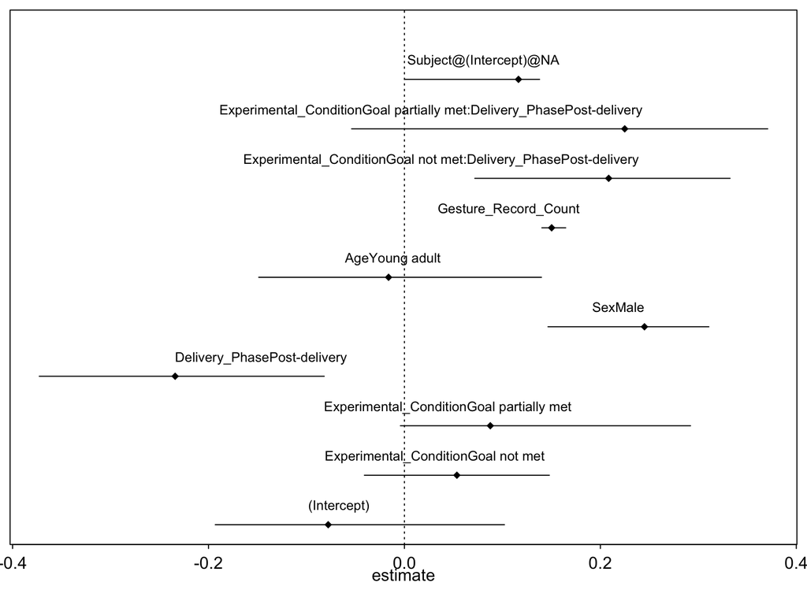

```r
m.stab.plot(full.gtype.stab$summary[, -1], 3)
```

```r
setwd("/Users/ve/Desktop/PhD/Analysis/Chapter 2 - Experiment/results/Model 3 - Diversity")
write.table(full.gtype.stab.rd, file="Mstab_GLMM_gtypes.csv", row.names=T, col.names=T, sep="\t")
```

The model is very unstable for the Intercept, Age, and some interaction terms so we decided not to interpret the findings but to provide them as Supplementary Information for reference.

## Supplementary Results

### Full-null model comparison

```r
null.gtype=glmer(Gesture_Type_Count ~ Experimental_Condition + Delivery_Phase + Age + Sex + Gesture_Record_Count
            + (1 | Subject),
            data = xdata,
            family=poisson)

Chisq.gtype<-round(as.data.frame(anova(null.gtype, full.gtype, test="Chisq")), 3)
Chisq.gtype
```

```
##            npar     AIC     BIC   logLik -2*log(L) Chisq Df Pr(>Chisq)
## null.gtype    8 292.987 313.748 -138.493   276.987    NA NA         NA
## full.gtype   10 296.556 322.507 -138.278   276.556 0.431  2      0.806
```

```r
setwd("/Users/ve/Desktop/PhD/Analysis/Chapter 2 - Experiment/results/Model 3 - Diversity")
write.table(Chisq.gtype, file="Chisq_GLMM_gtypes.csv", row.names=T, col.names=T, sep="\t")

#But check correlation of Gesture_Type_Count (gesture type n) and Gesture_Record_Count (gesture token n)
cor_gtype_gtok=cor.test(xdata$Gesture_Type_Count, xdata$Gesture_Record_Count, method = "pearson")
cor_gtype_gtok
```

```
##
##  Pearson's product-moment correlation
##
## data:  xdata$Gesture_Type_Count and xdata$Gesture_Record_Count
## t = 16.626, df = 97, p-value < 2.2e-16
## alternative hypothesis: true correlation is not equal to 0
## 95 percent confidence interval:
##  0.7986102 0.9042114
## sample estimates:
##       cor
## 0.8603789
```

The full-null model comparison is non-significant, meaning the predictors in the full model significantly do not improve the fit of the model. However, the model is unstable (See model stability) and number of gesture tokens and number of gesture types are strongly correlated (see below), possibly leading to a loss of statistical power.

### Supplementary Post-hoc tests for pre-delivery phase

```r
emm.gtype <- emmeans(full.gtype, ~ Experimental_Condition * Delivery_Phase)

pw.comp.gtype.phase <- contrast(emm.gtype, interaction = c("pairwise", "pairwise"),
                                 by = "Delivery_Phase")
posthoc.gtype.phase <- summary(pw.comp.gtype.phase, adjust = "tukey")
posthoc.gtype.phase.rd <- as.data.frame(lapply(posthoc.gtype.phase, function(x) {
  if(is.numeric(x)) round(x, 3) else x
}))
posthoc.gtype.phase.rd
```

```
##     Experimental_Condition_pairwise Delivery_Phase estimate    SE  df z.ratio
## 1           Goal met - Goal not met   Pre-delivery   -0.054 0.231 Inf  -0.232
## 2     Goal met - Goal partially met   Pre-delivery   -0.088 0.230 Inf  -0.382
## 3 Goal not met - Goal partially met   Pre-delivery   -0.034 0.231 Inf  -0.148
## 4           Goal met - Goal not met  Post-delivery   -0.262 0.301 Inf  -0.870
## 5     Goal met - Goal partially met  Post-delivery   -0.313 0.294 Inf  -1.062
## 6 Goal not met - Goal partially met  Post-delivery   -0.050 0.263 Inf  -0.192
##   p.value
## 1   0.971
## 2   0.923
## 3   0.988
## 4   0.659
## 5   0.538
## 6   0.980
```

```r
setwd("/Users/ve/Desktop/PhD/Analysis/Chapter 2 - Experiment/results/Model 3 - Diversity")
write.table(posthoc.gtype.phase.rd, file="Posthoc_Res_GLMM_gtype_predel.csv", row.names=T, col.names=T, sep="\t")
```

# Save working directory

```r
setwd("/Users/ve/Desktop/PhD/Analysis/Chapter 2 - Experiment")
save.image("Experiment analysis.Rdata")
```